# typhoon

Rikiya Honda

01/20/2021

# Foreword

This is R code for `typhoon` data set. The objective is to visualise no. of typhoon hitting Japan on monthly basis. I used term columns a lot in this article, so if you are not familier with columns (and rows), [this website](https://www.guru99.com/difference-between-rows-and-columns.html) will help you the different between columns and rows.

# Import data

The below code works anywhere you use R. I upload the data to third party file sharing service, and so you do not need to import csv. data file from your local computer. The following code load data to your local R.

```r
# get the url
url <- "https://raw.githubusercontent.com/Ricky-s-a/R_tutoring/main/Data/typhoon.csv"

# set the dataset named as `typhoon`
typhoon <- read.csv(url)
```

```r
# check the data set before assing the name to each column
head(typhoon)
```

```
##   ï..ãƒ.EN X1ãƒ.Eãƒ.E X2ãƒ.Eãƒ.E X3ãƒ.Eãƒ.E X4ãƒ.Eãƒ.E X5ãƒ.Eãƒ.E X6ãƒ.Eãƒ.E
## 1     1951         NA         NA         NA         NA         NA         NA
## 2     1952         NA         NA         NA         NA         NA          1
## 3     1953         NA         NA         NA         NA         NA          1
## 4     1954         NA         NA         NA         NA         NA         NA
## 5     1955         NA         NA         NA         NA         NA         NA
## 6     1956         NA         NA         NA          1         NA         NA
##   X7ãƒ.Eãƒ.E X8ãƒ.Eãƒ.E X9ãƒ.Eãƒ.E X10ãƒ.Eãƒ.E X11ãƒ.Eãƒ.E X12ãƒ.Eãƒ.E
## 1          1         NA         NA           1          NA          NA
## 2          1          1         NA          NA          NA          NA
## 3         NA         NA          1          NA          NA          NA
## 4         NA          1          4          NA          NA          NA
## 5          1         NA          1           2          NA          NA
## 6         NA          1          1          NA          NA          NA
##   ãƒ.ENãƒ.Eï..
## 1            2
## 2            3
## 3            2
## 4            5
## 5            4
## 6            3
```

# Tidy data

Since the columns of `typhoon` make no sense at all, we need to assign the name attribute to each column.

```r
# reset names of the columns
columns <- c("year", month.abb, "annual_sum")

# assign the name to each column of `typhoon`
typhoon <- `names<-`(typhoon, columns)

# check
head(typhoon)
```

```
##   year Jan Feb Mar Apr May Jun Jul Aug Sep Oct Nov Dec annual_sum
## 1 1951  NA  NA  NA  NA  NA  NA   1  NA  NA   1  NA  NA          2
## 2 1952  NA  NA  NA  NA  NA   1   1   1  NA  NA  NA  NA          3
## 3 1953  NA  NA  NA  NA  NA   1  NA  NA   1  NA  NA  NA          2
## 4 1954  NA  NA  NA  NA  NA  NA  NA   1   4  NA  NA  NA          5
## 5 1955  NA  NA  NA  NA  NA  NA   1  NA   1   2  NA  NA          4
## 6 1956  NA  NA  NA   1  NA  NA  NA   1   1  NA  NA  NA          3
```

As you can see, now each column has each month abbreviation, so it easily to understand what each columns refers to.

# Visualization

Next, we will plot a barplot by using `barplot()` function.

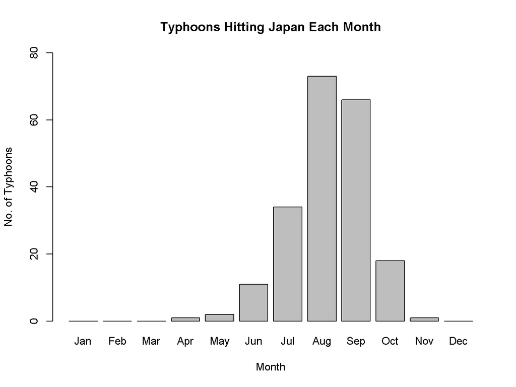

```r
# no. of typhoons hitting japan each month
y <- apply(typhoon[1:70, 2:13], 2, sum, na.rm = TRUE)

# plot a bar plot
barplot(y,
        ylim=c(0,80),
        xlab='Month',
        ylab = 'No. of Typhoons',
        main='Typhoons Hitting Japan Each Month')
```

That’s all for required code this time.

# All code

```r
# get the url
url <- "https://raw.githubusercontent.com/Ricky-s-a/R_tutoring/main/Data/typhoon.csv"

typhoon <- read.csv(url)

# reset names of the columns
columns <- c("year", month.abb, "annual_sum")
typhoon <- `names<-`(typhoon, columns)

# check
head(typhoon)


# no. of typhoons hitting japan each month
y <- apply(typhoon[1:70, 2:13], 2, sum, na.rm = TRUE)

# plot a bar plot
barplot(y,
        ylim=c(0,80),
        xlab='Month',
        ylab = 'No. of Typhoons',
        main='Typhoons Hitting Japan Each Month')
```

# Answers’ to questions

## 25 Jan 2022, 18:03

```r
# import data
# typhoon <- read.csv("dirct_path")


# reset names of the columns
columns<-c("year",month.abb[month.abb],"annual_sum")
typhoon<-`names<-`(typhoon,columns)

# check
 head(typhoon)
```

```
##   year NA NA NA NA NA NA NA NA NA NA NA NA annual_sum
## 1 1951 NA NA NA NA NA NA  1 NA NA  1 NA NA          2
## 2 1952 NA NA NA NA NA  1  1  1 NA NA NA NA          3
## 3 1953 NA NA NA NA NA  1 NA NA  1 NA NA NA          2
## 4 1954 NA NA NA NA NA NA NA  1  4 NA NA NA          5
## 5 1955 NA NA NA NA NA NA  1 NA  1  2 NA NA          4
## 6 1956 NA NA NA  1 NA NA NA  1  1 NA NA NA          3
```

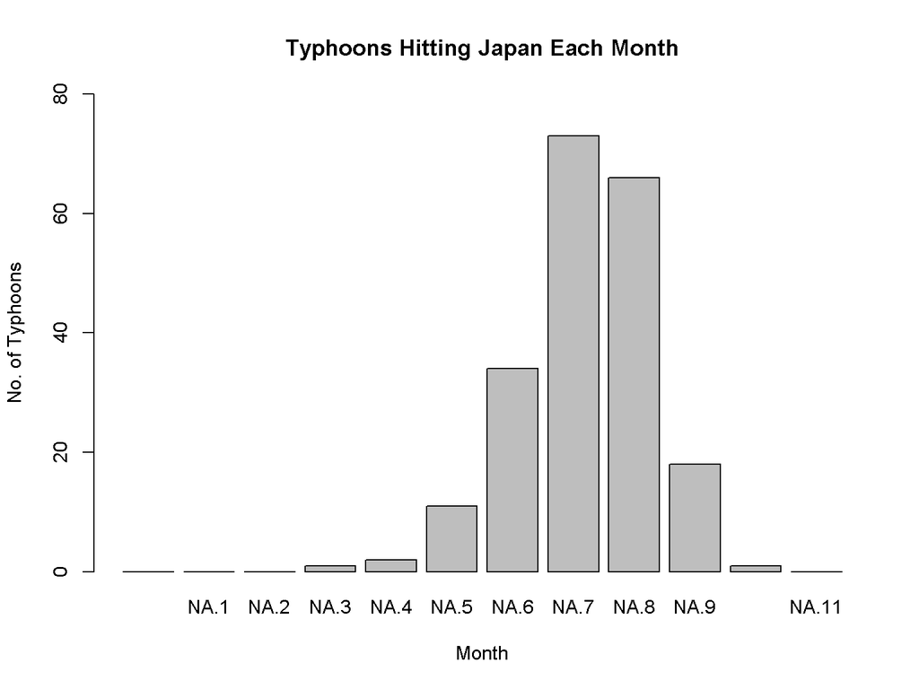

```r
# no. of typhoon hitting japan each month
y<-apply(typhoon[1:70,2:13],2,sum,na.rm=TRUE)

# plot bar plot
barplot(y,ylim=c(0,80),xlab='Month',ylab='No. of Typhoons',main='Typhoons Hitting Japan Each Month')
```

### Ansewer

I wasn’t clear enough to break down the `columns" part.

#### The Solution:

Please replace `columns <- c("year", month.abb[month.abb], "annual_sum")` with `columns <- c("year", month.abb, "annual_sum")`.

```r
columns <- c("year", month.abb, "annual_sum")
```

#### The Explanation:

As a brief explanation, `month.abb` is a sequence of the month’s name stored in R, so we don’t have to import it from anywhere else. If we simply write `month.abb`, and then the below result would be shown.

```r
month.abb
```

```
##  [1] "Jan" "Feb" "Mar" "Apr" "May" "Jun" "Jul" "Aug" "Sep" "Oct" "Nov" "Dec"
```

And so now, if we write `c("year",month.abb,"annual_sum")`, it automatically means `c("year", "Jan", "Feb", "Mar", "Apr", "May", "Jun", "Jul", "Aug", "Sep", "Oct", "Nov", "Dec", "annual_sum")`.

```r
# both codes are the same
# the short one
c("year", month.abb, "annual_sum")
```

```
##  [1] "year"       "Jan"        "Feb"        "Mar"        "Apr"
##  [6] "May"        "Jun"        "Jul"        "Aug"        "Sep"
## [11] "Oct"        "Nov"        "Dec"        "annual_sum"
```

```r
# the long one
c("year", "Jan", "Feb", "Mar",  "Apr", "May", "Jun", "Jul", "Aug", "Sep", "Oct", "Nov", "Dec", "annual_sum")
```

```
##  [1] "year"       "Jan"        "Feb"        "Mar"        "Apr"
##  [6] "May"        "Jun"        "Jul"        "Aug"        "Sep"
## [11] "Oct"        "Nov"        "Dec"        "annual_sum"
```

Please bear in mind that `c("year", "Jan", ..., "Dec", "annual_sum")` is just names and has not yet connected to the dataset `typhoon`.

To connect column names with the dataset, we need to run: `` typhoon<- `names<-` (typhoon,columns) ``

The above code means `columns` (name info) is assigned to the columns to the dataset `typhoon`. This might sound weird but probably the below comparison would give you a clear understanding.

**<Before assigning “columns” (name info) to `typhoon`>**

```r
# the original `typhoon` dataset
typhoon_before <- read.csv(url)

# show
head(typhoon_before)
```

```
##   ï..ãƒ.EN X1ãƒ.Eãƒ.E X2ãƒ.Eãƒ.E X3ãƒ.Eãƒ.E X4ãƒ.Eãƒ.E X5ãƒ.Eãƒ.E X6ãƒ.Eãƒ.E
## 1     1951         NA         NA         NA         NA         NA         NA
## 2     1952         NA         NA         NA         NA         NA          1
## 3     1953         NA         NA         NA         NA         NA          1
## 4     1954         NA         NA         NA         NA         NA         NA
## 5     1955         NA         NA         NA         NA         NA         NA
## 6     1956         NA         NA         NA          1         NA         NA
##   X7ãƒ.Eãƒ.E X8ãƒ.Eãƒ.E X9ãƒ.Eãƒ.E X10ãƒ.Eãƒ.E X11ãƒ.Eãƒ.E X12ãƒ.Eãƒ.E
## 1          1         NA         NA           1          NA          NA
## 2          1          1         NA          NA          NA          NA
## 3         NA         NA          1          NA          NA          NA
## 4         NA          1          4          NA          NA          NA
## 5          1         NA          1           2          NA          NA
## 6         NA          1          1          NA          NA          NA
##   ãƒ.ENãƒ.Eï..
## 1            2
## 2            3
## 3            2
## 4            5
## 5            4
## 6            3
```

**<After assigning “columns” (name info) to `typhoon`>**

```r
# reset names of the columns
columns<-c("year",month.abb[month.abb],"annual_sum")
typhoon<-`names<-`(typhoon,columns)

# show
head(typhoon)
```

```
##   year NA NA NA NA NA NA NA NA NA NA NA NA annual_sum
## 1 1951 NA NA NA NA NA NA  1 NA NA  1 NA NA          2
## 2 1952 NA NA NA NA NA  1  1  1 NA NA NA NA          3
## 3 1953 NA NA NA NA NA  1 NA NA  1 NA NA NA          2
## 4 1954 NA NA NA NA NA NA NA  1  4 NA NA NA          5
## 5 1955 NA NA NA NA NA NA  1 NA  1  2 NA NA          4
## 6 1956 NA NA NA  1 NA NA NA  1  1 NA NA NA          3
```

Once you set the naming of columns, this information is passed to the function `barplot()`, so automatically the plot of the x-axis becomes the abbreviation of months.